# Module Five Activity

For the module five activity, you will write Python code to create clear and informative data visualizations from the provided data set `Most-Recent-Cohorts-Field-of-Study.csv`. Your code should be well-organized and reflect a clear understanding of each step in the visualization process.

*Note:* there are two parts to this assignment. Part One is the data visualization coding activity. Part Two is the reflection paper.

Once your code is complete, you will download this notebook as an HTML file by clicking **File**, then **Download As**, then **HTML (.html)** from the Jupyter menu bar. Validate that your code, output, and all six visualizations (rendered as images using the display() function) are visible in the html file before submission.

*Missing Blocks:* Ensure that you have clicked **Run** for all blocks before downloading as an HTML file or the block may be missing from your submission. **Images** must be called using the *display()* function, for example: **display(Image(filename="output/{image_name}.png"))**

Specifically, you must address the items from the rubric criteria.

### Part One: Data Visualization

#### Prepare the given data set for visualization. Consider the following:

- Are there any columns you can remove?
- Are filters or groupings needed?
- Are the data values structured for your chart types?

#### Clean the given data set for visualization using Python. Consider the following:

- Are there any missing or invalid values?
- Are there any unclear column names?
- Are the data types correct for each column (e.g., numeric, categorical, datetime)?

#### Create multiple types of visualizations using Python. Include the following:

- Dendrogram
- PCA scatterplot
- Cluster size distribution
- Feature importance heatmap
- Trend chart
- Scatterplot

*Note:* You will need to ensure that you have created at least one of each of the visual types listed above.

### Part 2: Reflection

*This part is to be completed in a word document, using the output here to answer the topics.*

#### Identify patterns in the data. Consider the following:

- Are there any clear trends, clusters, or outliers visible in your visualizations?
- Are certain variables showing consistent behavior or relationships?
- Are the patterns similar across different visualization types?

#### Draw conclusions from the patterns. Consider the following:

- Are your conclusions clearly based on the patterns you observed?
- Are your findings supported by multiple visuals or data points?

#### Explain how the visualizations validate your findings. Consider the following:

- Are specific chart elements (e.g., color, scale, labels) helping to highlight your findings?
- Are the insights you found something you could not easily see without the visuals?

#### Write a summary of the visualization choices you made. Include the following:

- An explanation of the types of charts you used
- An explanation of the formatting decisions to support visual clarity

*To Begin:* This Python template program has been broken down into segments as a guide for what steps you should do at a minimum to complete this activity. Look for the **# To Do:** comments. These are placeholders for you to provide Python code segments. Fill out all **# To Do:** code segments to complete this program.  
*Once Complete:* Execute a "Kernel restart and run all" to verify that all your code works as a single unit by clicking **Kernel**, then **Restart & Run All** before downloading as html.

*Hint:* If you need to install additional packages, see one of the earlier modules on how to configure and call a requirements.txt file.

## Import the Required Packages

- **pandas (pd):** For reading and manipulating the dataset.
- **MinMaxScaler:** A preprocessing tool from sklearn to normalize data values between 0 and 1.
- **PCA:** Principal Component Analysis (dimensionality reduction) from sklearn for visualizing clusters in 2D.
- **dendrogram, linkage, fcluster:** Tools from scipy for performing hierarchical clustering and visualizing its results.
- **matplotlib.pyplot (plt):** For creating charts and saving visuals.
- **seaborn (sns):** For advanced and visually appealing charts.
- **numpy (np):** For numerical operations like arrays and aggregations.

```python
import pandas as pd   # for reading & manipulating the dataset
from sklearn.preprocessing import MinMaxScaler    # a preprocessing tool from sklearn to normalize data values
                                                                                    # between 0 and 1
from sklearn.decomposition import PCA  # Principal Component Analysis (dimensionality reduction) from
                                                                   # sklearn for visualizing clusters in 2D
from scipy.cluster.hierarchy import dendrogram, linkage, fcluster,set_link_color_palette    # tools from scipy for performing hierarchical clustering & visualizing its results
import matplotlib.pyplot as plt     #  for creating charts & saving visuals
import seaborn as sns    #  for advanced & visually appealing charts
import numpy as np      # for numerical operations like arrays & aggregations

from IPython.display import Image, display # for image rendering in html output

import os
import matplotlib.pyplot as plt
```

# Part One: Data Visualization

## Loading the Data

*Hints:* Use **pd.read_csv** to read a CSV file and load it into a DataFrame (data). Use **try block** to ensures the program handles errors gracefully if the file cannot be loaded (e.g., missing or incorrect path). Use **exit()** to stop the program if an error occurs.

```python
print("Loading dataset...")
# To Do: Use the given dataset named "Most-Recent-Cohorts-Field-of-Study.csv" for this assignment
# Load this dataset
# For secure coding, put this action in a try/catch block

try:
    data_file = pd.read_csv("data/Most-Recent-Cohorts-Field-of-Study.csv")
    print("Dataset has been loaded")

except FileNotFoundError:
    print("Unable to locate file, please try again")
    exit()
```

```
Loading dataset...
Dataset has been loaded
```

## Display Dataset Information

*Hints:* Use **data.columns.tolist()** to extract and print all column names. Use **data.index.tolist()** to show the index values of the dataset (e.g., row numbers). Use **data.head()** to display the top 5 rows to give an overview of the data.

```python
print("Column Names:")
# To Do: Print all column names
data_file.columns.tolist()
```

```
Column Names:
```

```
['UNITID',
 'OPEID6',
 'INSTNM',
 'CONTROL',
 'MAIN',
 'CIPCODE',
 'CIPDESC',
 'CREDLEV',
 'CREDDESC',
 'IPEDSCOUNT1',
 'IPEDSCOUNT2',
 'DEBT_ALL_STGP_ANY_N',
 'DEBT_ALL_STGP_ANY_MEAN',
 'DEBT_ALL_STGP_ANY_MDN',
 'DEBT_ALL_STGP_EVAL_N',
 'DEBT_ALL_STGP_EVAL_MEAN',
 'DEBT_ALL_STGP_EVAL_MDN',
 'DEBT_ALL_PP_ANY_N',
 'DEBT_ALL_PP_ANY_MEAN',
 'DEBT_ALL_PP_ANY_MDN',
 'DEBT_ALL_PP_EVAL_N',
 'DEBT_ALL_PP_EVAL_MEAN',
 'DEBT_ALL_PP_EVAL_MDN',
 'DEBT_MALE_STGP_ANY_N',
 'DEBT_MALE_STGP_ANY_MEAN',
 'DEBT_MALE_STGP_ANY_MDN',
 'DEBT_MALE_STGP_EVAL_N',
 'DEBT_MALE_STGP_EVAL_MEAN',
 'DEBT_MALE_STGP_EVAL_MDN',
 'DEBT_MALE_PP_ANY_N',
 'DEBT_MALE_PP_ANY_MEAN',
 'DEBT_MALE_PP_ANY_MDN',
 'DEBT_MALE_PP_EVAL_N',
 'DEBT_MALE_PP_EVAL_MEAN',
 'DEBT_MALE_PP_EVAL_MDN',
 'DEBT_NOTMALE_STGP_ANY_N',
 'DEBT_NOTMALE_STGP_ANY_MEAN',
 'DEBT_NOTMALE_STGP_ANY_MDN',
 'DEBT_NOTMALE_STGP_EVAL_N',
 'DEBT_NOTMALE_STGP_EVAL_MEAN',
```

[output cut: 119 more lines]

```
 'DISTANCE',
 'EARN_COUNT_NWNE_5YR',
 'EARN_COUNT_WNE_5YR',
 'EARN_MDN_5YR',
 'EARN_GT_THRESHOLD_5YR',
 'EARN_COUNT_PELL_WNE_5YR',
 'EARN_PELL_WNE_MDN_5YR',
 'EARN_COUNT_NOPELL_WNE_5YR',
 'EARN_NOPELL_WNE_MDN_5YR',
 'EARN_COUNT_MALE_WNE_5YR',
 'EARN_MALE_WNE_MDN_5YR',
 'EARN_COUNT_NOMALE_WNE_5YR',
 'EARN_NOMALE_WNE_MDN_5YR',
 'EARN_COUNT_HIGH_CRED_5YR',
 'EARN_IN_STATE_5YR']
```

```python
print("Row Index Labels:")
# To Do: Print all row data Labels
data_file.index.tolist()
```

```
Row Index Labels:
```

[output not shown]

[output cut: 946 more lines]

[output not shown]

```python
print("First 5 Rows of the Dataset:")
# To Do: Print the first 5 rows of the dataset
data_file.head()
```

```
First 5 Rows of the Dataset:
```

|  | UNITID | OPEID6 | INSTNM | CONTROL | MAIN | CIPCODE | CIPDESC | CREDLEV | CREDDESC | IPEDSCOUNT1 | ... | EARN_COUNT_PELL_WNE_5YR | EARN_PELL_WNE_MDN_5YR | EARN_COUNT_NOPELL_WNE_5YR | EARN_NOPELL_WNE_MDN_5YR | EARN_COUNT_MALE_WNE_5YR | EARN_MALE_WNE_MDN_5YR | EARN_COUNT_NOMALE_WNE_5YR | EARN_NOMALE_WNE_MDN_5YR | EARN_COUNT_HIGH_CRED_5YR | EARN_IN_STATE_5YR |
| --- | --- | --- | --- | --- | --- | --- | --- | --- | --- | --- | --- | --- | --- | --- | --- | --- | --- | --- | --- | --- | --- |
| 0 | 100654.0 | 1002 | Alabama A & M University | Public | 1 | 100 | Agriculture, General. | 3 | Bachelor's Degree | NaN | ... | PS | PS | PS | PS | PS | PS | PS | PS | PS | PS |
| 1 | 100654.0 | 1002 | Alabama A & M University | Public | 1 | 101 | Agricultural Business and Management. | 3 | Bachelor's Degree | NaN | ... | PS | PS | PS | PS | PS | PS | PS | PS | PS | PS |
| 2 | 100654.0 | 1002 | Alabama A & M University | Public | 1 | 109 | Animal Sciences. | 3 | Bachelor's Degree | 3.0 | ... | PS | PS | PS | PS | PS | PS | PS | PS | PS | PS |
| 3 | 100654.0 | 1002 | Alabama A & M University | Public | 1 | 110 | Food Science and Technology. | 3 | Bachelor's Degree | 7.0 | ... | PS | PS | PS | PS | PS | PS | PS | PS | PS | PS |
| 4 | 100654.0 | 1002 | Alabama A & M University | Public | 1 | 110 | Food Science and Technology. | 5 | Master's Degree | 4.0 | ... | PS | PS | PS | PS | PS | PS | PS | PS | PS | PS |

5 rows × 174 columns

```python
# The following is breakdown of the meaning of the different
# column labels in the dataset to aid with determining the
# information provided in the data set. This information was
# obtained from https://collegescorecard.ed.gov/data/glossary/
# provided by the US Department of Education:

# IPEDSCOUNT1: the number of degrees awarded in this field of study
# by the listed education institution in the first year of analysis

# IPEDSCOUNT2: the number of degrees awarded in this field of study
# by the listed education institution in the second year of analysis

# DEBT_ALL_STGP_ANY_MDN: the median federal student loan debt per
# education institution per degree type earned

# EARN_MDN: the median earnings of students

# WNE: Working and not enrolled

# NE: Not employed

# NWNE: Not working and not enrolled

# BBRR: Borrower-Based Repayment Rate

# PS: Privacy Suppressed,information is not provided

# HI: includes students who went to receive more higher education
# upon graduation
```

```python
# Prepare the given data set for visualization. Consider the following:
#A. Are there any columns you can remove? Per the assignment instructions
#the UNITID and OPEID6 columns should be removed; additionally, the dataset
#can be further reduced to remove information that is brokenout by student
#gender or information regarding the interest rate on the student loans

#B. Are filters or groupings needed? The columns sometime contain PS which from
# above means that the information was not provided; therefore, these columns
# should be removed since they do not provide any useful information

#C. Are the data values structured for your chart types? It appears that a
# majority of the data is not numeric even though the columns contain data that
# is numerical in nature. These columns will be updated to be a numerical type
# to further aid in the data analysis
```

```python
# Clean the given data set for visualization using Python. Consider the following:
#A. Are there any missing or invalid values? As described above there are frequent
# PS values recorded which indicate that the data was not made available for the
# given institution and program leading to other related cells having N/A values
# since the information was not made available. These have to be removed in order to
# properly perform the hierarchical clustering since N/A or infinite values cannot be
# included in the data set

#B. Are there any unclear column names? Yes, as described in section 6 research was
# necessary in order to determine the meaning and purpose of the columns names, the
# relevant columns names will be updated to enhance understandability

#C. Are the data types correct for each column (e.g., numeric, categorical, datetime)?
# A numberic conversion is necessary as described above to ensure that the numeric values
# represented in the data are actually numeric types for data analysis purposes
```

```python
# Renaming of revelant columns to enhance understandability
# of the data analysis. For the purposes of this analysis
# information on the BBRR (Borrower-Based Repayment Rate)
# and information broken out by gender or type of federal
# loan or scholarship (i.e. Pell Grant or Non-Pell Grant)
# will not be renamed and converted to numberical values
# to enhance the analysis by focusing on total student loans
# and income earned by degree program for the listed
# education institutions

renamed_data = data_file.rename(
columns={'INSTNM': 'Institution Name',
 'CONTROL': 'Institution Type',
 'MAIN': 'Main or Branch',
 'CIPCODE': 'Field of Study ID',
 'CIPDESC': 'Degree Awarded',
 'CREDLEV': 'Credit Level',
 'CREDDESC': 'Education Level',
 'IPEDSCOUNT1': 'Number of Degrees- Year 1',
 'IPEDSCOUNT2': 'Number of Degrees- Year 2',
 'DEBT_ALL_STGP_ANY_MEAN': 'Mean Federal Student Loan',
 'DEBT_ALL_STGP_ANY_MDN': 'Median Federal Student Loan',
 'EARN_MDN_HI_1YR': 'Median Income & Addtl Education: Year 1',
 'EARN_MDN_HI_2YR': 'Median Income & Addtl Education: Year 2',
 'EARN_NE_MDN_3YR': 'Median Income for Graduate: Year 3', # per the government website this columns presents the Year 3 data
 'EARN_MDN_1YR': 'Median Income for Graduate: Year 1',
 'EARN_MDN_4YR': 'Median Income for Graduate: Year 4',
 'EARN_MDN_5YR': 'Median Income for Graduate: Year 5'
})
```

```python
columns_to_keep = ['UNITID','OPEID6','Institution Name', 'Institution Type', 'Main or Branch', 'Field of Study ID', 'Degree Awarded',
                 'Credit Level',  'Education Level',  'Number of Degrees- Year 1', 'Number of Degrees- Year 2',
                   'Mean Federal Student Loan', 'Median Federal Student Loan', 'Median Income & Addtl Education: Year 1',
                   'Median Income & Addtl Education: Year 2', 'Median Income for Graduate: Year 3',
                   'Median Income for Graduate: Year 1', 'Median Income for Graduate: Year 4', 'Median Income for Graduate: Year 5']

cleaned_data = renamed_data[columns_to_keep]
cleaned_data
```

|  | UNITID | OPEID6 | Institution Name | Institution Type | Main or Branch | Field of Study ID | Degree Awarded | Credit Level | Education Level | Number of Degrees- Year 1 | Number of Degrees- Year 2 | Mean Federal Student Loan | Median Federal Student Loan | Median Income & Addtl Education: Year 1 | Median Income & Addtl Education: Year 2 | Median Income for Graduate: Year 3 | Median Income for Graduate: Year 1 | Median Income for Graduate: Year 4 | Median Income for Graduate: Year 5 |
| --- | --- | --- | --- | --- | --- | --- | --- | --- | --- | --- | --- | --- | --- | --- | --- | --- | --- | --- | --- |
| 0 | 100654.0 | 1002 | Alabama A & M University | Public | 1 | 100 | Agriculture, General. | 3 | Bachelor's Degree | NaN | NaN | PS | PS | PS | PS | PS | PS | PS | PS |
| 1 | 100654.0 | 1002 | Alabama A & M University | Public | 1 | 101 | Agricultural Business and Management. | 3 | Bachelor's Degree | NaN | NaN | PS | PS | NaN | NaN | NaN | PS | PS | PS |
| 2 | 100654.0 | 1002 | Alabama A & M University | Public | 1 | 109 | Animal Sciences. | 3 | Bachelor's Degree | 3.0 | 9.0 | PS | PS | PS | PS | PS | PS | PS | PS |
| 3 | 100654.0 | 1002 | Alabama A & M University | Public | 1 | 110 | Food Science and Technology. | 3 | Bachelor's Degree | 7.0 | 10.0 | PS | PS | PS | PS | PS | PS | PS | PS |
| 4 | 100654.0 | 1002 | Alabama A & M University | Public | 1 | 110 | Food Science and Technology. | 5 | Master's Degree | 4.0 | 6.0 | PS | PS | PS | PS | PS | PS | PS | PS |
| ... | ... | ... | ... | ... | ... | ... | ... | ... | ... | ... | ... | ... | ... | ... | ... | ... | ... | ... | ... |
| 229183 | NaN | 43006 | Southeast New Mexico College | Public | 1 | 5201 | Business/Commerce, General. | 2 | Associate's Degree | NaN | NaN | NaN | NaN | NaN | NaN | NaN | PS | NaN | PS |
| 229184 | NaN | 43006 | Southeast New Mexico College | Public | 1 | 5203 | Accounting and Related Services. | 1 | Undergraduate Certificate or Diploma | NaN | NaN | NaN | NaN | NaN | NaN | NaN | PS | NaN | PS |
| 229185 | NaN | 43006 | Southeast New Mexico College | Public | 1 | 5204 | Business Operations Support and Assistant Serv... | 1 | Undergraduate Certificate or Diploma | NaN | NaN | NaN | NaN | NaN | NaN | NaN | PS | NaN | PS |
| 229186 | NaN | 43006 | Southeast New Mexico College | Public | 1 | 5204 | Business Operations Support and Assistant Serv... | 2 | Associate's Degree | NaN | NaN | NaN | NaN | NaN | NaN | NaN | PS | NaN | PS |
| 229187 | NaN | 43006 | Southeast New Mexico College | Public | 1 | 5214 | Marketing. | 3 | Bachelor's Degree | NaN | NaN | NaN | NaN | NaN | NaN | NaN | PS | NaN | PS |

229188 rows × 19 columns

```python
# To ensure that numerical columns are int64 type before performing
# further analysis

exclude_cols = ['Institution Name', 'Institution Type','Main or Branch', 'Degree Awarded', 'Education Level']
final_cleaned_data = cleaned_data.copy()

for col in final_cleaned_data.columns:
    if col not in exclude_cols:
        final_cleaned_data[col] = pd.to_numeric(final_cleaned_data[col], errors='coerce')

print(final_cleaned_data)
```

```
          UNITID  OPEID6              Institution Name Institution Type
0       100654.0    1002      Alabama A & M University           Public  \
1       100654.0    1002      Alabama A & M University           Public
2       100654.0    1002      Alabama A & M University           Public
3       100654.0    1002      Alabama A & M University           Public
4       100654.0    1002      Alabama A & M University           Public
...          ...     ...                           ...              ...
229183       NaN   43006  Southeast New Mexico College           Public
229184       NaN   43006  Southeast New Mexico College           Public
229185       NaN   43006  Southeast New Mexico College           Public
229186       NaN   43006  Southeast New Mexico College           Public
229187       NaN   43006  Southeast New Mexico College           Public

        Main or Branch  Field of Study ID
0                    1                100  \
```

[output cut: 116 more lines]

```python
# To remove all non-numerical values from the revelant columns

final_cleaned_data= final_cleaned_data.dropna()
display(final_cleaned_data)
```

|  | UNITID | OPEID6 | Institution Name | Institution Type | Main or Branch | Field of Study ID | Degree Awarded | Credit Level | Education Level | Number of Degrees- Year 1 | Number of Degrees- Year 2 | Mean Federal Student Loan | Median Federal Student Loan | Median Income & Addtl Education: Year 1 | Median Income & Addtl Education: Year 2 | Median Income for Graduate: Year 3 | Median Income for Graduate: Year 1 | Median Income for Graduate: Year 4 | Median Income for Graduate: Year 5 |
| --- | --- | --- | --- | --- | --- | --- | --- | --- | --- | --- | --- | --- | --- | --- | --- | --- | --- | --- | --- |
| 39 | 100654.0 | 1002 | Alabama A & M University | Public | 1 | 2401 | Liberal Arts and Sciences, General Studies and... | 3 | Bachelor's Degree | 32.0 | 13.0 | 32054.0 | 33000.0 | 23094.0 | 24615.0 | 30613.0 | 28877.0 | 39750.0 | 46627.0 |
| 66 | 100663.0 | 1052 | University of Alabama at Birmingham | Public | 1 | 901 | Communication and Media Studies. | 3 | Bachelor's Degree | 90.0 | 99.0 | 26312.0 | 26000.0 | 28940.0 | 29517.0 | 33859.0 | 33190.0 | 40729.0 | 39661.0 |
| 90 | 100663.0 | 1052 | University of Alabama at Birmingham | Public | 1 | 1313 | Teacher Education and Professional Development... | 3 | Bachelor's Degree | 121.0 | 142.0 | 24668.0 | 24573.0 | 30620.0 | 29882.0 | 33214.0 | 32093.0 | 38487.0 | 47189.0 |
| 109 | 100663.0 | 1052 | University of Alabama at Birmingham | Public | 1 | 1419 | Mechanical Engineering. | 3 | Bachelor's Degree | 33.0 | 39.0 | 24556.0 | 26354.0 | 63241.0 | 59253.0 | 73433.0 | 58191.0 | 78456.0 | 87901.0 |
| 118 | 100663.0 | 1052 | University of Alabama at Birmingham | Public | 1 | 2301 | English Language and Literature, General. | 3 | Bachelor's Degree | 42.0 | 48.0 | 25487.0 | 24946.0 | 27282.0 | 27497.0 | 25437.0 | 32324.0 | 40560.0 | 36019.0 |
| ... | ... | ... | ... | ... | ... | ... | ... | ... | ... | ... | ... | ... | ... | ... | ... | ... | ... | ... | ... |
| 218828 | 495998.0 | 21207 | San Joaquin Valley College-Porterville | Private, for-profit | 0 | 5108 | Allied Health and Medical Assisting Services. | 1 | Undergraduate Certificate or Diploma | 82.0 | 57.0 | 10890.0 | 10269.0 | 21439.0 | 21861.0 | 23522.0 | 26897.0 | 27686.0 | 30548.0 |
| 218829 | 495998.0 | 21207 | San Joaquin Valley College-Porterville | Private, for-profit | 0 | 5204 | Business Operations Support and Assistant Serv... | 1 | Undergraduate Certificate or Diploma | 19.0 | 11.0 | 9525.0 | 9500.0 | 23322.0 | 22094.0 | 24032.0 | 27731.0 | 29398.0 | 35845.0 |
| 218849 | 496292.0 | 23068 | Miller-Motte College-Chattanooga 2 | Private, for-profit | 0 | 4902 | Ground Transportation. | 1 | Undergraduate Certificate or Diploma | 0.0 | 47.0 | 12662.0 | 7875.0 | 42409.0 | 30988.0 | 30343.0 | 46909.0 | 39461.0 | 29387.0 |
| 218850 | 496326.0 | 21785 | Eagle Gate College-Boise Campus | Private, for-profit | 0 | 5108 | Allied Health and Medical Assisting Services. | 1 | Undergraduate Certificate or Diploma | 0.0 | 4.0 | 12756.0 | 12931.0 | 27589.0 | 25658.0 | 21986.0 | 32150.0 | 29011.0 | 34023.0 |
| 218853 | 496371.0 | 42067 | Elite Welding Academy South Point | Private, for-profit | 0 | 4805 | Precision Metal Working. | 1 | Undergraduate Certificate or Diploma | 12.0 | 4.0 | 9477.0 | 9500.0 | 45212.0 | 37478.0 | 46401.0 | 38717.0 | 48013.0 | 52408.0 |

17755 rows × 19 columns

## Inspect and Select Numeric Columns

*Hints:* Use **select_dtypes()** to filter columns with numeric data types (float64 and int64). Removes columns like **UNITID** and **OPEID6**, which are not useful for clustering. Use **dropna()** to remove rows with missing values to clean data for clustering, see also module three sample for additional cleaning examples. Use error handling **try blocks** to ensures the program stops if the column selection fails.

```python
print("Inspecting dataset to select numeric columns for clustering...")
# To Do: In a try/catch block, exclude identifiers 'UNITID' and 'OPEID6',
# then print the numeric columns selected for clustering and also print the data for clustering in rows & columns

# Additionally the Main or Branch, Field of Study ID, and Credit Level columns
# were also removed since they would not be useful in further analysis as they are just
# numerical IDs that do not have any inheritant values like (loan balance or
# median income)

columns_to_drop = ['UNITID','OPEID6', 'Main or Branch', 'Field of Study ID','Credit Level']

try:
    renamed_data = final_cleaned_data.drop(columns=columns_to_drop)
    data_file_cluster = renamed_data.copy()
    numeric_cols = data_file_cluster.select_dtypes(include=['number']).columns.tolist() #number was utilized instead
    # of select_dtypes()
    cluster_data = data_file_cluster[numeric_cols]

    print('Numeric columns selected for clustering:')
    print(numeric_cols)
    print('\n' + '=' * 50 + '\n')
    print('Data for clustering (Rows & Columns):')
    display(cluster_data)

except Exception as e:
  print(f'An error occurred: {e}')
```

```
Inspecting dataset to select numeric columns for clustering...
Numeric columns selected for clustering:
['Number of Degrees- Year 1', 'Number of Degrees- Year 2', 'Mean Federal Student Loan', 'Median Federal Student Loan', 'Median Income & Addtl Education: Year 1', 'Median Income & Addtl Education: Year 2', 'Median Income for Graduate: Year 3', 'Median Income for Graduate: Year 1', 'Median Income for …

==================================================

Data for clustering (Rows & Columns):
```

|  | Number of Degrees- Year 1 | Number of Degrees- Year 2 | Mean Federal Student Loan | Median Federal Student Loan | Median Income & Addtl Education: Year 1 | Median Income & Addtl Education: Year 2 | Median Income for Graduate: Year 3 | Median Income for Graduate: Year 1 | Median Income for Graduate: Year 4 | Median Income for Graduate: Year 5 |
| --- | --- | --- | --- | --- | --- | --- | --- | --- | --- | --- |
| 39 | 32.0 | 13.0 | 32054.0 | 33000.0 | 23094.0 | 24615.0 | 30613.0 | 28877.0 | 39750.0 | 46627.0 |
| 66 | 90.0 | 99.0 | 26312.0 | 26000.0 | 28940.0 | 29517.0 | 33859.0 | 33190.0 | 40729.0 | 39661.0 |
| 90 | 121.0 | 142.0 | 24668.0 | 24573.0 | 30620.0 | 29882.0 | 33214.0 | 32093.0 | 38487.0 | 47189.0 |
| 109 | 33.0 | 39.0 | 24556.0 | 26354.0 | 63241.0 | 59253.0 | 73433.0 | 58191.0 | 78456.0 | 87901.0 |
| 118 | 42.0 | 48.0 | 25487.0 | 24946.0 | 27282.0 | 27497.0 | 25437.0 | 32324.0 | 40560.0 | 36019.0 |
| ... | ... | ... | ... | ... | ... | ... | ... | ... | ... | ... |
| 218828 | 82.0 | 57.0 | 10890.0 | 10269.0 | 21439.0 | 21861.0 | 23522.0 | 26897.0 | 27686.0 | 30548.0 |
| 218829 | 19.0 | 11.0 | 9525.0 | 9500.0 | 23322.0 | 22094.0 | 24032.0 | 27731.0 | 29398.0 | 35845.0 |
| 218849 | 0.0 | 47.0 | 12662.0 | 7875.0 | 42409.0 | 30988.0 | 30343.0 | 46909.0 | 39461.0 | 29387.0 |
| 218850 | 0.0 | 4.0 | 12756.0 | 12931.0 | 27589.0 | 25658.0 | 21986.0 | 32150.0 | 29011.0 | 34023.0 |
| 218853 | 12.0 | 4.0 | 9477.0 | 9500.0 | 45212.0 | 37478.0 | 46401.0 | 38717.0 | 48013.0 | 52408.0 |

17755 rows × 10 columns

## Normalize the Data

*Hints:* Use **MinMaxScaler()** to scale data values between 0 and 1, ensuring all features are on the same scale. Use **fit_transform()** to fit the scaler to the data and transform it.

```python
print("Normalizing the data using MinMaxScaler...")
# To Do: in a try/catch block, normalize the data using MinMaxScaler

numeric_columns = cluster_data.select_dtypes(include=["number"])
try:
    scaler_obj = MinMaxScaler()
    scaled_array = scaler_obj.fit_transform(numeric_columns)
    normalized_data = pd.DataFrame(scaled_array, columns=numeric_columns.columns)
    print("Normalization successful:")
    display(normalized_data)
except Exception as error_message:
    print(f"An error occurred during normalization: {error_message}")
```

```
Normalizing the data using MinMaxScaler...
Normalization successful:
```

|  | Number of Degrees- Year 1 | Number of Degrees- Year 2 | Mean Federal Student Loan | Median Federal Student Loan | Median Income & Addtl Education: Year 1 | Median Income & Addtl Education: Year 2 | Median Income for Graduate: Year 3 | Median Income for Graduate: Year 1 | Median Income for Graduate: Year 4 | Median Income for Graduate: Year 5 |
| --- | --- | --- | --- | --- | --- | --- | --- | --- | --- | --- |
| 0 | 0.003523 | 0.001353 | 0.572324 | 0.552511 | 0.116835 | 0.128921 | 0.180054 | 0.151571 | 0.147315 | 0.130882 |
| 1 | 0.009910 | 0.010306 | 0.455145 | 0.424658 | 0.161930 | 0.167086 | 0.199146 | 0.181134 | 0.152317 | 0.103955 |
| 2 | 0.013323 | 0.014782 | 0.421595 | 0.398594 | 0.174890 | 0.169928 | 0.195352 | 0.173615 | 0.140862 | 0.133055 |
| 3 | 0.003634 | 0.004060 | 0.419309 | 0.431123 | 0.426525 | 0.398597 | 0.431905 | 0.352500 | 0.345067 | 0.290427 |
| 4 | 0.004625 | 0.004997 | 0.438309 | 0.405406 | 0.149141 | 0.151359 | 0.149611 | 0.175198 | 0.151454 | 0.089877 |
| ... | ... | ... | ... | ... | ... | ... | ... | ... | ... | ... |
| 17750 | 0.009029 | 0.005934 | 0.140423 | 0.137333 | 0.104068 | 0.107480 | 0.138348 | 0.137999 | 0.085679 | 0.068729 |
| 17751 | 0.002092 | 0.001145 | 0.112567 | 0.123288 | 0.118594 | 0.109294 | 0.141347 | 0.143716 | 0.094426 | 0.089204 |
| 17752 | 0.000000 | 0.004893 | 0.176585 | 0.093607 | 0.265829 | 0.178538 | 0.178466 | 0.275169 | 0.145839 | 0.064241 |
| 17753 | 0.000000 | 0.000416 | 0.178503 | 0.185954 | 0.151509 | 0.137041 | 0.129313 | 0.174005 | 0.092449 | 0.082161 |
| 17754 | 0.001321 | 0.000416 | 0.111587 | 0.123288 | 0.287451 | 0.229067 | 0.272913 | 0.219018 | 0.189531 | 0.153229 |

17755 rows × 10 columns

## Perform Hierarchical Clustering

*Hints:* Use **linkage()** to compute hierarchical clusters using **Ward's** method, which minimizes variance between clusters. Limit clustering to the first 1000 rows for performance. Use **fcluster()** to assign cluster labels to data points based on the number of clusters (max_clusters).

```python
print("Performing hierarchical clustering using Ward's method...")
# To Do: in a try/catch block use the Ward's method to perform hierarchical clustering, limit max clusters to 4.
try:
            max_clusters = 4
            data_for_clustering = normalized_data.iloc[:1000].copy()
            Z = linkage(data_for_clustering.values, method='ward')
            cluster_labels = fcluster(Z, t=max_clusters, criterion='maxclust')
            data_for_clustering['cluster'] = cluster_labels
            print(f"Assigned cluster labels (1..{max_clusters}) to {len(data_for_clustering)} rows")
            display(data_for_clustering['cluster'].value_counts().sort_index())
            plt.figure(figsize=(10, 6))
            dendrogram(Z, p=30, truncate_mode='lastp', show_leaf_counts=True, leaf_rotation=90)
            plt.title("Truncated Dendrogram (Ward)")
            plt.xlabel("Cluster size")
            plt.ylabel("Distance")
            plt.close()
except Exception as e:
            print(f"An error occurred performing hierarchical clustering: {e}")
```

```
Performing hierarchical clustering using Ward's method...
Assigned cluster labels (1..4) to 1000 rows
```

```
cluster
1    220
2    375
3    133
4    272
Name: count, dtype: int64
```

```python
# The hierarchial clustering using Ward's method grouped the
# 1,000 rows of data into the specified 4 clusters. 220 data
# elements were in the first cluster, 375 were in the second
# cluster, 133 were in the third cluster, and 272 were in the
# fourth cluster
```

## Generate, Save, and Output Visualizations

Each visualization is created, saved and displayed, with text output provided before and after.

### Dendrogram

*Hints:* A dendrogram displays the hierarchical structure of clusters. Save the image as **dendrogram.png**. Use **display()** to render the image for html file output. Do not use an html image tag in the markdown, or the image will not print in the html download.

```python
print("Creating Dendrogram visualization display...")
# To Do: create a dendrogram to visualize hierarchical clustering and save it as a PNG
output_dir = "output"
os.makedirs(output_dir, exist_ok=True)
output_path = os.path.join(output_dir, "dendrogram.png")

try:

    max_clusters = 4
    data_for_clustering = normalized_data.iloc[:1000].copy()
    Z = linkage(data_for_clustering.values, method='ward')
    cluster_labels = fcluster(Z, t=max_clusters, criterion='maxclust')
    data_for_clustering['cluster'] = cluster_labels
    print(f"Assigned cluster labels (1..{max_clusters}) to {len(data_for_clustering)} rows")
    display(data_for_clustering['cluster'].value_counts().sort_index())
    threshold = Z[-(max_clusters - 1), 2]
    cluster_color_map = {1: 'tab:blue', 2: 'tab:orange', 3: 'tab:green', 4: 'tab:red'}

    link_lookup = {i + len(data_for_clustering): (int(Z[i, 0]), int(Z[i, 1])) for i in range(Z.shape[0])}
    cluster_color_cache = {}

    def get_link_color(node_id):
        if node_id < len(data_for_clustering):
            return cluster_color_map[cluster_labels[node_id]]
        if node_id in cluster_color_cache:
            return cluster_color_cache[node_id]

        left, right = link_lookup[node_id]
        left_color = get_link_color(left)
        right_color = get_link_color(right)

        color = left_color if left_color == right_color else 'black'
        cluster_color_cache[node_id] = color
        return color

    plt.figure(figsize=(10, 6))

    dendrogram(
    Z,
    p=60,
    truncate_mode='lastp',
    show_leaf_counts=True,
    leaf_rotation=90,
    color_threshold=threshold,
    link_color_func=get_link_color
)

    legend_handles = [plt.Line2D([0], [0], color=color, lw=4, label=f"Cluster {cluster}") for cluster, color in cluster_color_map.items()]
    plt.legend(handles=legend_handles, title="Cluster", loc='best')

    plt.title("Dendrogram (Ward)")
    plt.xlabel("Number of points in node (or index of point if no parenthesis)")
    plt.ylabel("Distance")
    plt.savefig(output_path)
    plt.close()

except Exception as e:
    print(f"An error occurred performing hierarchical clustering: {e}")
```

```
Creating Dendrogram visualization display...
Assigned cluster labels (1..4) to 1000 rows
```

```
cluster
1    220
2    375
3    133
4    272
Name: count, dtype: int64
```

```
Dendrogram visualization display...
```

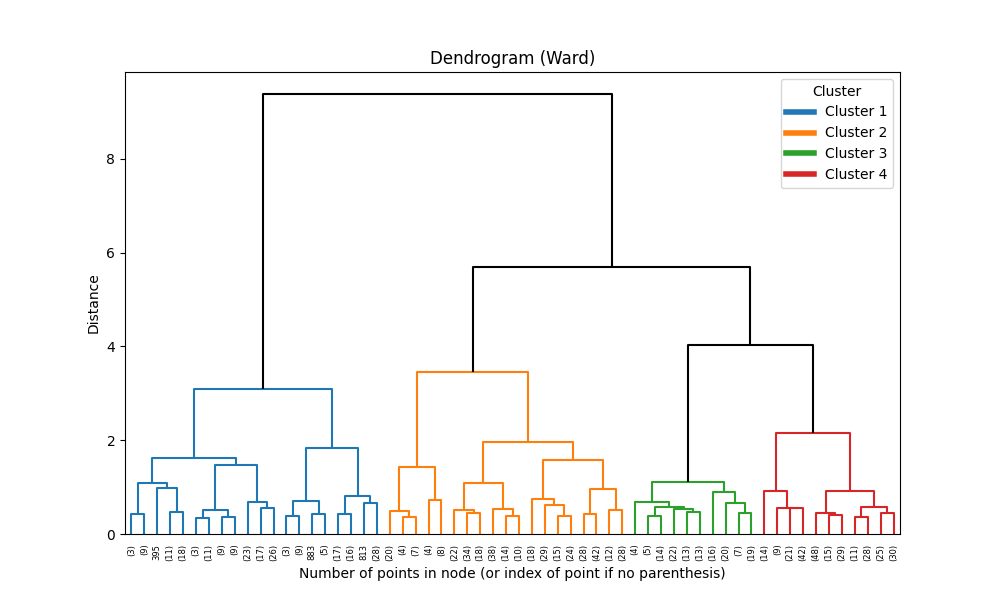

```python
print("Dendrogram visualization display...")
# To Do: output the image using the display() function, for example: display(Image(filename="output/scatter_plot.png"))

display(Image(filename='output/dendrogram.png'))
```

### PCA Scatter Plot

*Hints:* A PCA scatter plot projects high-dimensional data into 2D using PCA for visualization. Save the image as **pca_scatter_plot.png**. Use **display()** to render the image for html file output. Do not use an html image tag in the markdown, or the image will not print in the html download.

```python
print("Creating scatter plot (PCA Reduced) to visualize clusters in 2D...")
# To Do: Create a PCA Scatter Plot to visualize clusters in 2D, and save the PCA Scatter Plot into a png file under the 'output' folder.
try:
    pca_data = normalized_data.iloc[:data_for_clustering.shape[0]].copy()
    pca_model = PCA(n_components=2)
    pca_components = pca_model.fit_transform(pca_data.values)

    pca_df = pd.DataFrame(
        pca_components,
        columns=["PC1", "PC2"],
        index=pca_data.index,
    )
    pca_df["cluster"] = data_for_clustering["cluster"].values


    plt.figure(figsize=(10, 7))
    sns.scatterplot(
        data=pca_df,
        x="PC1",
        y="PC2",
        hue="cluster",
        palette="tab10",
        s=60,
        edgecolor="k",
        alpha=0.85,
    )

    cluster_stats = (
    pca_df.groupby("cluster")
    .agg(
        {
            "PC1": "mean",
            "PC2": "mean",
            "cluster": ["count", "first"],
        }
    )
)
    cluster_stats.columns = ["PC1_mean", "PC2_mean", "count", "cluster"]
    cluster_stats = cluster_stats.reset_index(drop=True)

    for _, row in cluster_stats.iterrows():
      label = f"Cluster {row['cluster']}\n(n={row['count']})"
      plt.text(
          row['PC1_mean'],
          row['PC2_mean'],
          label,
          horizontalalignment='center',
          verticalalignment='center',
          fontsize=10,
          fontweight='bold',
          bbox=dict(facecolor='white', alpha=0.7, edgecolor='gray', boxstyle='round,pad=0.3'),
      )
    plt.title("PCA Scatter Plot of Clustered Data")
    plt.xlabel("Principal Component 1")
    plt.ylabel("Principal Component 2")
    plt.legend(title="Cluster", loc="best")
    plt.tight_layout()


    output_dir = "output"
    os.makedirs(output_dir, exist_ok=True)
    pca_plot_path = os.path.join(output_dir, "pca_scatter_plot.png")
    plt.savefig(pca_plot_path, dpi=300, bbox_inches="tight")
    plt.close()

    print(f"PCA scatter plot saved to: {pca_plot_path}")



except Exception as e:
    print(f"An error occurred creating the PCA scatter plot: {e}")
```

```
Creating scatter plot (PCA Reduced) to visualize clusters in 2D...
PCA scatter plot saved to: output/pca_scatter_plot.png
```

```
PCA scatter plot visualization display...
```

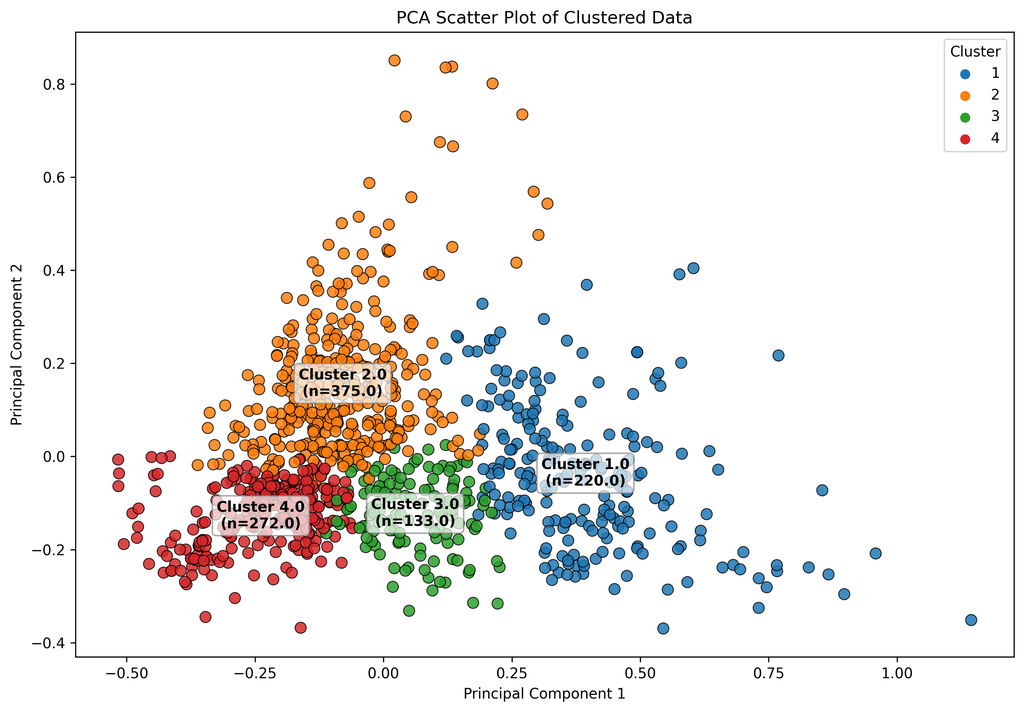

```python
print("PCA scatter plot visualization display...")
# To Do: output the image using the display() function, for example: display(Image(filename="output/pca_scatter_plot.png"))

display(Image(filename="output/pca_scatter_plot.png"))
```

### Cluster Size Distribution

*Hints:* A cluster size distribution displays the population size of each cluster. Save the image as **cluster_size.png**. Use **display()** to render the image for html file output. Do not use an html image tag in the markdown, or the image will not print in the html download.

```python
print("Creating cluster size distribution chart to analyze cluster populations...")
# To Do: Create a cluster size distribution chart, and save it into a png file under the 'output' folder.
try:
    cluster_counts = data_for_clustering["cluster"].value_counts().sort_index()

    plt.figure(figsize=(8, 6))
    sns.barplot(x=cluster_counts.index.astype(str), y=cluster_counts.values, palette="tab10")
    plt.title("Cluster Size Distribution")
    plt.xlabel("Cluster")
    plt.ylabel("Number of Records")

    ax = sns.barplot(x=cluster_counts.index.astype(str), y=cluster_counts.values, palette="tab10")
    for p in ax.patches:
        height = p.get_height()
        ax.annotate(
            f"{int(height)}",
            xy=(p.get_x() + p.get_width() / 2, height),
            xytext=(0, 3),
            textcoords="offset points",
            ha="center",
            va="bottom",
            fontsize=10,
        )
    plt.tight_layout()

    output_dir = "output"
    os.makedirs(output_dir, exist_ok=True)
    cluster_size_path = os.path.join(output_dir, "cluster_size.png")
    plt.savefig(cluster_size_path, dpi=300, bbox_inches="tight")
    plt.close()

    print(f"Cluster size distribution saved to: {cluster_size_path}")

except Exception as e:
    print(f"An error occurred creating the cluster size distribution chart: {e}")
```

```
Creating cluster size distribution chart to analyze cluster populations...
Cluster size distribution saved to: output/cluster_size.png
```

```
Cluster size distribution visualization display...
```

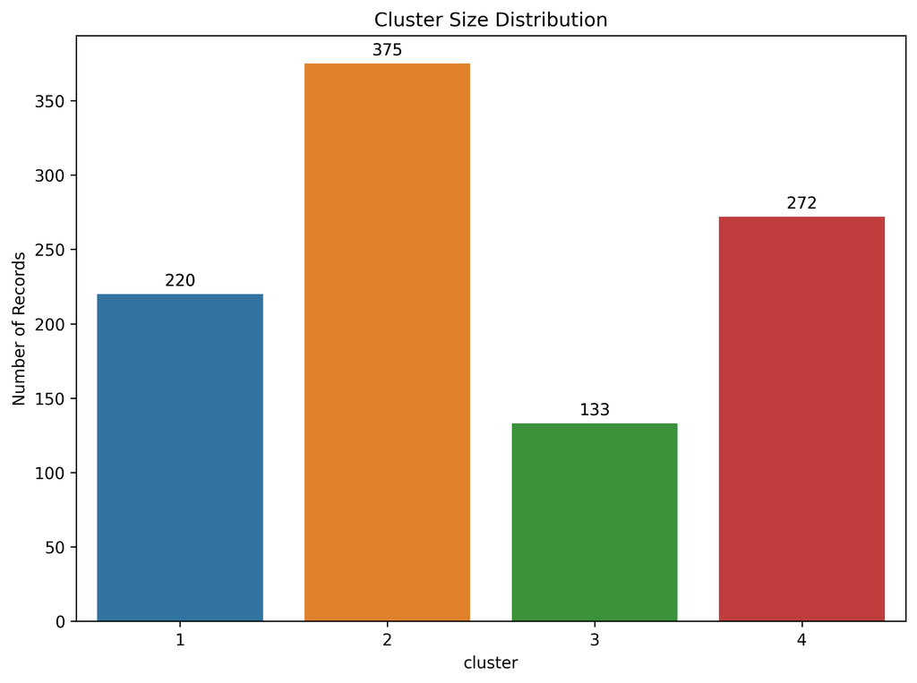

```python
print("Cluster size distribution visualization display...")
# To Do: output the image using the display() function, for example: display(Image(filename="output/cluster_size.png"))

display(Image(filename="output/cluster_size.png"))
```

### Feature Importance Heatmap

*Hints:* A feature importance heatmap highlights the average feature values for each cluster. Save the image as **heatmap.png**. Use **display()** to render the image for html file output. Do not use an html image tag in the markdown, or the image will not print in the html download.

```python
print("Creating feature importance heatmap to show mean feature values by cluster...")
# To Do: Create a feature importance heatmap, and save it into a png file under the 'output' folder.
try:
    feature_means = data_for_clustering.groupby("cluster").mean()

    plt.figure(figsize=(14, 10))
    sns.heatmap(
        feature_means,
        annot=False,
        cmap="viridis",
        cbar_kws={"label": "Average normalized value"},
    )
    plt.xticks(rotation=50, ha="right")
    plt.title("Feature Importance Heatmap by Cluster")
    plt.xlabel("Feature")
    plt.ylabel("Cluster")
    plt.tight_layout()

    output_dir = "output"
    os.makedirs(output_dir, exist_ok=True)
    heatmap_path = os.path.join(output_dir, "heatmap.png")
    plt.savefig(heatmap_path, dpi=300, bbox_inches="tight")
    plt.close()

    print(f"Feature importance heatmap saved to: {heatmap_path}")

except Exception as e:
    print(f"An error occurred creating the feature importance heatmap: {e}")
```

```
Creating feature importance heatmap to show mean feature values by cluster...
Feature importance heatmap saved to: output/heatmap.png
```

```
Feature important heatmap visualization display...
```

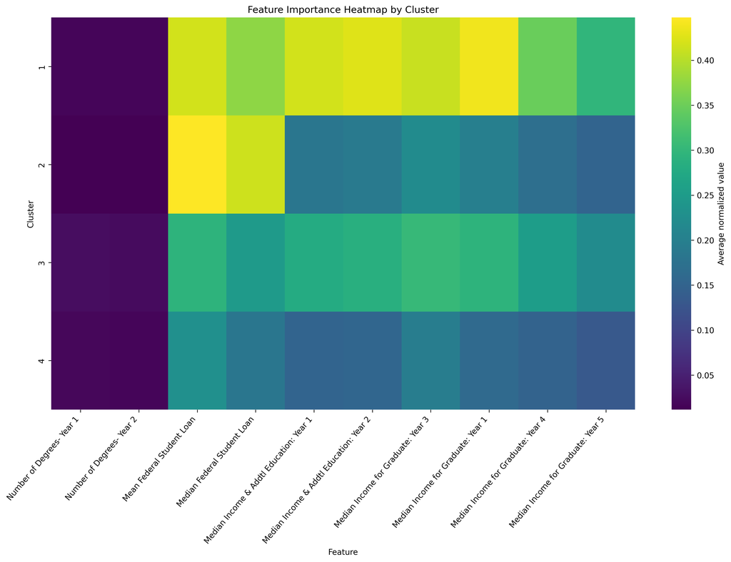

```python
print("Feature important heatmap visualization display...")
# To Do: output the image using the display() function, for example: display(Image(filename="output/heatmap.png"))

display(Image(filename="output/heatmap.png"))
```

### Trend Chart

*Hints:* A trend chart plots trends in a numeric feature across clusters. Save the image as **trend_chart.png**. Use **display()** to render the image for html file output. Do not use an html image tag in the markdown, or the image will not print in the html download.

```python
print("Creating trend chart to analyze a numeric feature across clusters...")
# To Do: Create a trend chart to analyze a numeric feature across clusters, and save it into a png file under the 'output' folder.
try:
    feature_columns = [col for col in data_for_clustering.columns if col != "cluster"]
    if not feature_columns:
        raise ValueError("No numeric feature columns available for trend analysis.")

    selected_feature = feature_columns[2]
    cluster_feature_trend = data_for_clustering.groupby("cluster")[selected_feature].mean().sort_index()

    plt.figure(figsize=(10, 6))
    sns.lineplot(x=cluster_feature_trend.index, y=cluster_feature_trend.values, marker="o")
    plt.title(f"Trend of Mean Federal Loans of Analysis Across Clusters")
    plt.xlabel("Cluster")
    plt.ylabel(f"Average {selected_feature}")
    plt.xticks(cluster_feature_trend.index)
    plt.tight_layout()

    output_dir = "output"
    os.makedirs(output_dir, exist_ok=True)
    trend_chart_path = os.path.join(output_dir, "trend_chart_federal_loans.png")
    plt.savefig(trend_chart_path, dpi=300, bbox_inches="tight")
    plt.close()

    print(f"Trend chart saved to: {trend_chart_path}")

except Exception as e:
    print(f"An error occurred creating the trend chart: {e}")
```

```
Creating trend chart to analyze a numeric feature across clusters...
Trend chart saved to: output/trend_chart_federal_loans.png
```

```
Trend chart visualization display...
```

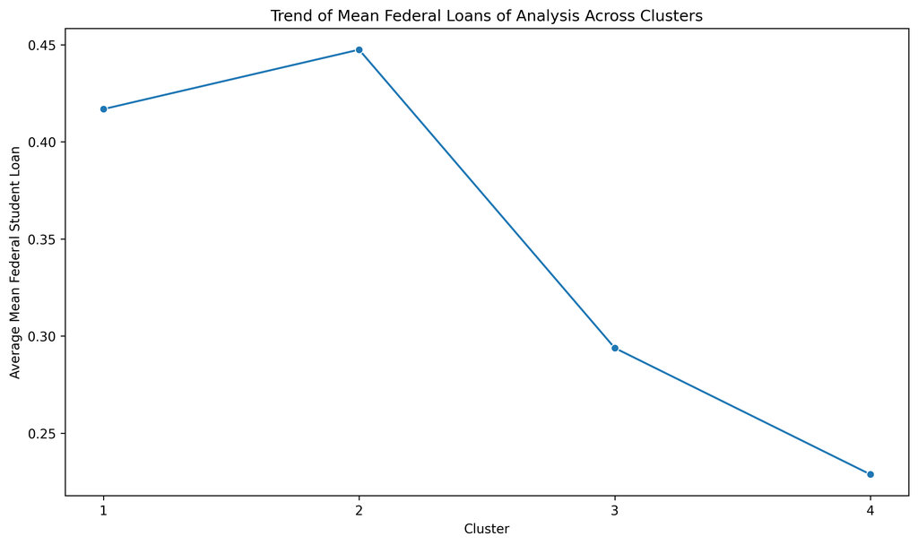

```python
print("Trend chart visualization display...")
# To Do: output the image using the display() function, for example: display(Image(filename="output/trend_chart.png"))

display(Image(filename="output/trend_chart_federal_loans.png"))
```

```python
print("Creating trend chart to analyze a numeric feature across clusters...")
# To Do: Create a trend chart to analyze a numeric feature across clusters, and save it into a png file under the 'output' folder.
try:
    feature_columns = [col for col in data_for_clustering.columns if col != "cluster"]
    if not feature_columns:
        raise ValueError("No numeric feature columns available for trend analysis.")

    selected_feature = feature_columns[7]
    cluster_feature_trend = data_for_clustering.groupby("cluster")[selected_feature].mean().sort_index()

    plt.figure(figsize=(10, 6))
    sns.lineplot(x=cluster_feature_trend.index, y=cluster_feature_trend.values, marker="o")
    plt.title(f"Trend of Median Income 1 Year After Graduation of Analysis Across Clusters")
    plt.xlabel("Cluster")
    plt.ylabel(f"Average {selected_feature}")
    plt.xticks(cluster_feature_trend.index)
    plt.tight_layout()

    output_dir = "output"
    os.makedirs(output_dir, exist_ok=True)
    trend_chart_path = os.path.join(output_dir, "trend_chart_median_income.png")
    plt.savefig(trend_chart_path, dpi=300, bbox_inches="tight")
    plt.close()

    print(f"Trend chart saved to: {trend_chart_path}")

except Exception as e:
    print(f"An error occurred creating the trend chart: {e}")
```

```
Creating trend chart to analyze a numeric feature across clusters...
Trend chart saved to: output/trend_chart_median_income.png
```

```
Trend chart visualization display...
```

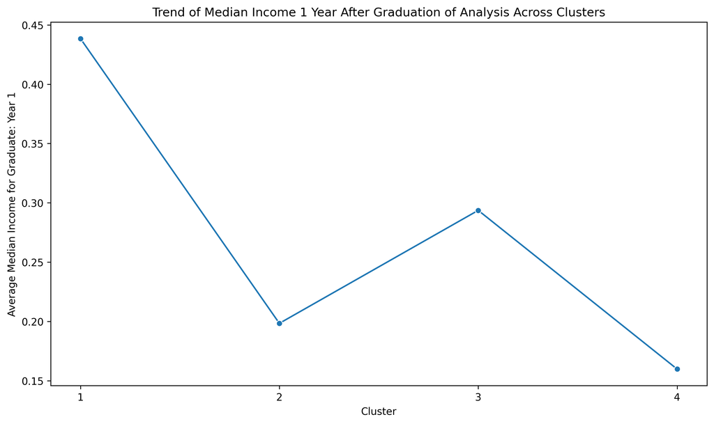

```python
print("Trend chart visualization display...")
# To Do: output the image using the display() function, for example: display(Image(filename="output/trend_chart.png"))

display(Image(filename="output/trend_chart_median_income.png"))
```

```python
print("Creating trend chart to analyze a numeric feature across clusters...")
# To Do: Create a trend chart to analyze a numeric feature across clusters, and save it into a png file under the 'output' folder.
cluster = "cluster"

try:
  if cluster not in data_for_clustering.columns:
    raise ValueError(f"Cluster column '{cluster}' not found in data.")

  feature_columns = [
      col for col in data_for_clustering.columns if col != cluster
  ]
  if len(feature_columns) < 2:
    raise ValueError(
        "At least two numeric feature columns are required for trend analysis."
    )


  feature1, feature2 = feature_columns[0], feature_columns[1]


  cluster_trends = (
      data_for_clustering.groupby(cluster)[[feature1, feature2]]
      .mean()
      .sort_index()
  )

  plt.figure(figsize=(10, 6))

  sns.lineplot(
      x=cluster_trends.index,
      y=cluster_trends[feature1],
      marker="o",
      label=feature1,
  )

  sns.lineplot(
      x=cluster_trends.index,
      y=cluster_trends[feature2],
      marker="s",
      label=feature2,
  )

  plt.title("Trend of Number of Degrees in Year 1 and Year 2 Across Clusters")
  plt.xlabel("Cluster")
  plt.ylabel("Average Value")
  plt.ylim(0, 0.45)
  plt.xticks(cluster_trends.index)
  plt.legend()
  plt.tight_layout()


  output_dir = "output"
  os.makedirs(output_dir, exist_ok=True)
  trend_chart_path = os.path.join(
      output_dir, "trend_chart_number_of_degrees.png"
  )

  plt.savefig(trend_chart_path, dpi=300, bbox_inches="tight")
  plt.close()

  print(f"Trend chart saved to: {trend_chart_path}")

except Exception as e:
  print(f"An error occurred creating the trend chart: {e}")
```

```
Creating trend chart to analyze a numeric feature across clusters...
Trend chart saved to: output/trend_chart_number_of_degrees.png
```

```
Trend chart visualization display...
```

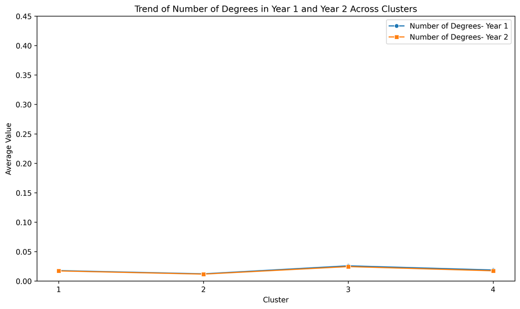

```python
print("Trend chart visualization display...")
# To Do: output the image using the display() function, for example: display(Image(filename="output/trend_chart.png"))

display(Image(filename="output/trend_chart_number_of_degrees.png"))
```

### Scatter Plot

*Hints:* A scatter plot explores the relationship between two features, grouped by clusters. Save the image as **scatter_plot.png**. Use **display()** to render the image for html file output. Do not use an html image tag in the markdown, or the image will not print in the html download.

```python
print("Creating scatter plot of two features...")
# To Do: Create a scatter plot of two features, and save it into a png file under the 'output' folder.
feature_columns = [col for col in data_for_clustering.columns if col != "cluster"]
if len(feature_columns) < 2:
    raise ValueError("At least two numeric features are required for a scatter plot.")

x_feature = feature_columns[7]
y_feature = feature_columns[6]

plt.figure(figsize=(10, 7))
sns.scatterplot(
    data=data_for_clustering,
    x=x_feature,
    y=y_feature,
    hue="cluster",
    palette="tab10",
    edgecolor="k",
    alpha=0.75,
    s=60,
)

plt.title(f"Scatter Plot of Income Received in Year 1 vs Received in Year 3 After Graduation by Cluster")
plt.xlabel(x_feature)
plt.ylabel(y_feature)
plt.legend(title="Cluster", loc="best")


min_val = min(
data_for_clustering[x_feature].min(), data_for_clustering[y_feature].min())
max_val = max(data_for_clustering[x_feature].max(), data_for_clustering[y_feature].max())
plt.plot(
[min_val, max_val],
[min_val, max_val],
color="black",
linestyle="--",
linewidth=1.5,
label="y=x",)

output_dir = "output"
os.makedirs(output_dir, exist_ok=True)
scatter_plot_path = os.path.join(output_dir, "scatter_plot.png")
plt.savefig(scatter_plot_path, dpi=300, bbox_inches="tight")
plt.close()

print(f"Scatter plot saved to: {scatter_plot_path}")
```

```
Creating scatter plot of two features...
Scatter plot saved to: output/scatter_plot.png
```

```
Scatter plot visualization display...
```

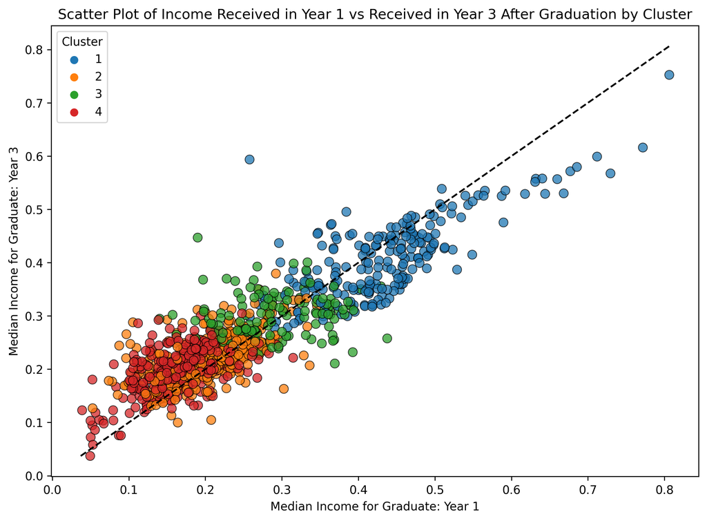

```python
print("Scatter plot visualization display...")
# To Do: output the image using the display() function, for example: display(Image(filename="output/scatter_plot.png"))

display(Image(filename="output/scatter_plot.png"))
```

```python
print("Creating scatter plot of two features...")
# To Do: Create a scatter plot of two features, and save it into a png file under the 'output' folder.
try:
    feature_columns = [col for col in data_for_clustering.columns if col != "cluster"]
    if len(feature_columns) < 2:
        raise ValueError("At least two numeric features are required for a scatter plot.")

    x_feature = feature_columns[7]
    y_feature = feature_columns[2]

    plt.figure(figsize=(10, 7))
    sns.scatterplot(
        data=data_for_clustering,
        x=x_feature,
        y=y_feature,
        hue="cluster",
        palette="tab10",
        edgecolor="k",
        alpha=0.75,
        s=60,
    )
    plt.title(f"Scatter Plot of Income Received in Year 1 vs Mean Federal Student Loan Balance by Cluster")
    plt.xlabel(x_feature)
    plt.ylabel(y_feature)
    plt.legend(title="Cluster", loc="best")


    min_val = min(
    data_for_clustering[x_feature].min(), data_for_clustering[y_feature].min()
    )
    max_val = max(
    data_for_clustering[x_feature].max(), data_for_clustering[y_feature].max()
    )

    plt.tight_layout()
    output_dir = "output"
    os.makedirs(output_dir, exist_ok=True)
    scatter_plot_path = os.path.join(output_dir, "scatter_plot_loan.png")
    plt.savefig(scatter_plot_path, dpi=300, bbox_inches="tight")
    plt.close()

    print(f"Scatter plot saved to: {scatter_plot_path}")

except Exception as e:
    print(f"An error occurred creating the scatter plot: {e}")
```

```
Creating scatter plot of two features...
Scatter plot saved to: output/scatter_plot_loan.png
```

```
Scatter plot visualization display...
```

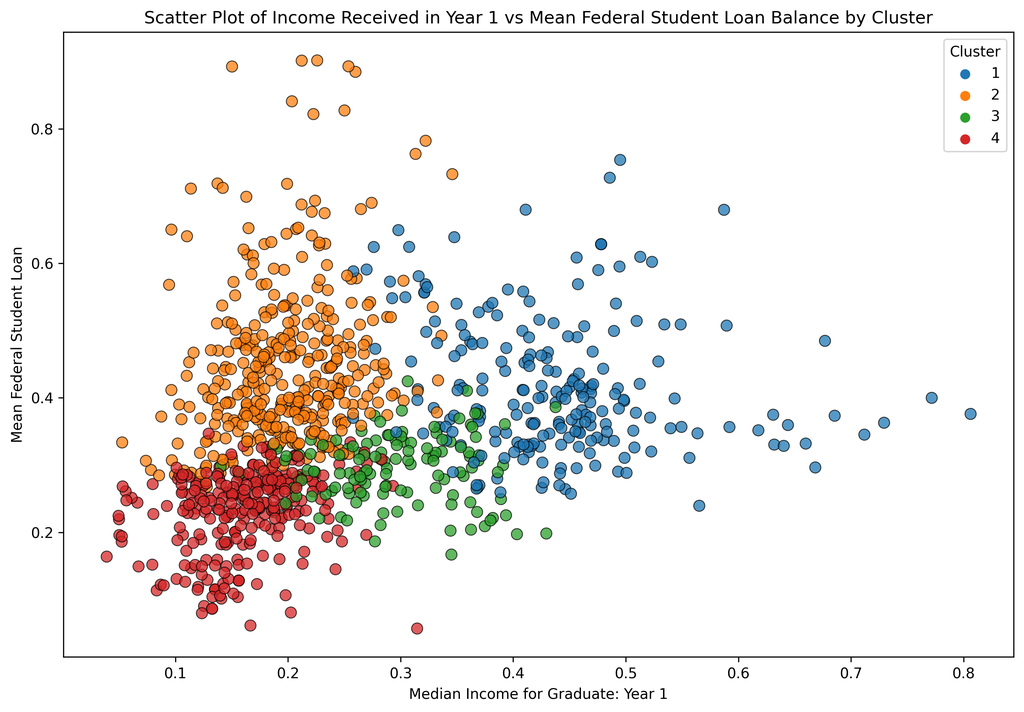

```python
print("Scatter plot visualization display...")
# To Do: output the image using the display() function, for example: display(Image(filename="output/scatter_plot.png"))

display(Image(filename="output/scatter_plot_loan.png"))
```